# IODS course project

Next we will create some summary graphs.

```r
n <- 11

# Summary data with mean and standard error of weight by treatment and week
RATSS <- RATS %>%
  group_by(Group, Time) %>%
  summarise( mean = mean(Weight), n=n(), se = sd(Weight)/sqrt(n)) %>%
  ungroup()
```

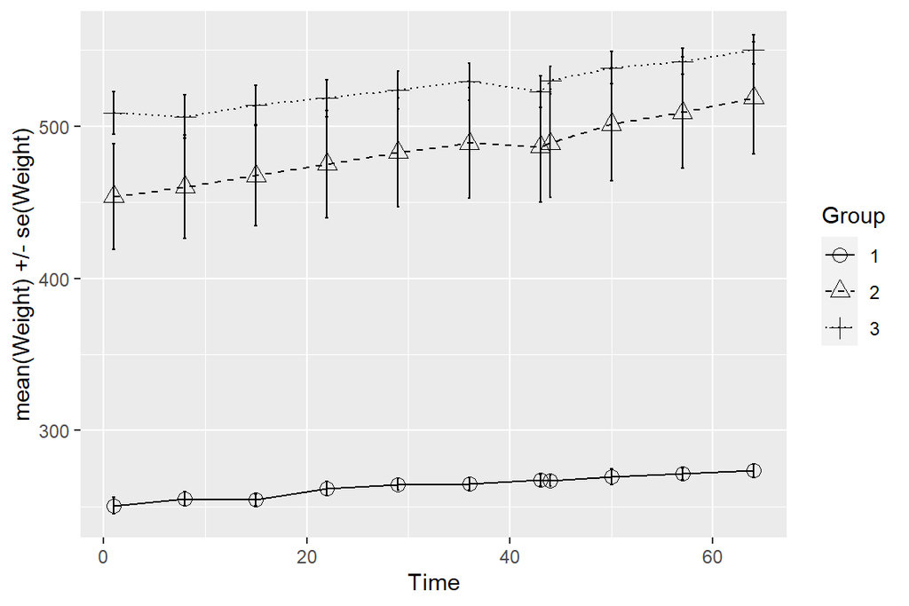

```r
# Plot the mean profiles
ggplot(RATSS, aes(x = Time, y = mean, linetype = Group, shape = Group)) +
  geom_line() +
  scale_linetype_manual(values = c(1,2,3)) +
  geom_point(size=3) +
  scale_shape_manual(values = c(1,2,3)) +
  geom_errorbar(aes(ymin=mean-se, ymax=mean+se, linetype="1"), width=0.3) +
  scale_y_continuous(name = "mean(Weight) +/- se(Weight)")
```

We can see that the weight seems to increase over time in all groups. Weight is largest in group 3, then 2 and finally 1.

We will use the mean of days 8-64 as the summary measure to look how the different treatments affect the weight. We will also remove some outliers.

```r
# Create a summary data by group and ID with mean as the summary variable (ignoring baseline day 1)
RATS_summary <- RATS %>%
  filter(Time > 1) %>%
  group_by(Group, ID) %>%
  summarise( mean=mean(Weight) ) %>%
  ungroup()
```

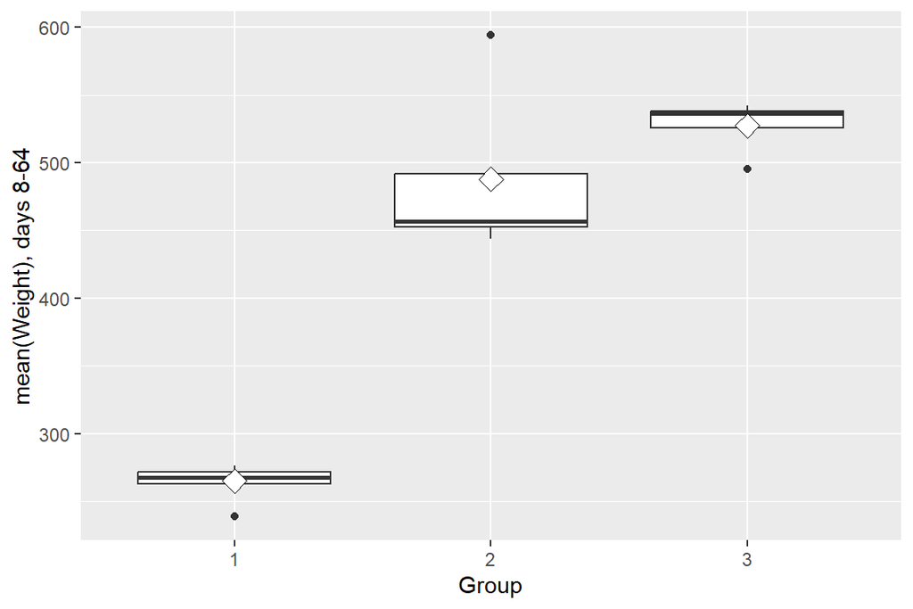

```r
# Draw a boxplot of the mean versus group
ggplot(RATS_summary, aes(x = Group, y = mean)) +
  geom_boxplot() +
  stat_summary(fun = "mean", geom = "point", shape=23, size=4, fill = "white") +
  scale_y_continuous(name = "mean(Weight), days 8-64")
```

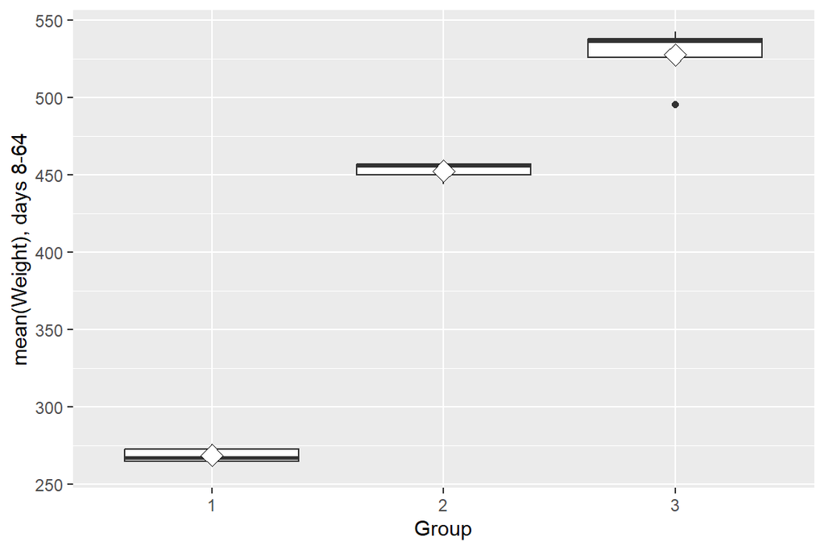

```r
# Create a new data by filtering the outliers and adjust the ggplot code the draw the plot again with the new data
RATS_summary_no_outliers <- RATS_summary %>% filter(mean >250 & mean <550)
ggplot(RATS_summary_no_outliers, aes(x = Group, y = mean)) +
  geom_boxplot() +
  stat_summary(fun = "mean", geom = "point", shape=23, size=4, fill = "white") +
  scale_y_continuous(name = "mean(Weight), days 8-64")
```

After removing the outliers the variation in the groups is significantly reduced. There is still the above mentioned differences in the weight. However, we cannot really make any conclusions with these results, as they are mainly affected by the baseline weight. We can use ANOVA to account for this.

```r
# Add the baseline from the original data as a new variable to the summary data
RATS_summary <- RATS_summary %>%
  mutate(baseline = RATS_original$WD1)

# Fit the linear model with the mean as the response
fit <- lm(mean ~ baseline+Group, data = RATS_summary)

# Compute the analysis of variance table for the fitted model
anova(fit)
```

```
## Analysis of Variance Table
##
## Response: mean
##           Df Sum Sq Mean Sq   F value   Pr(>F)
## baseline   1 253625  253625 1859.8201 1.57e-14 ***
## Group      2    879     439    3.2219  0.07586 .
## Residuals 12   1636     136
## ---
## Signif. codes:  0 '***' 0.001 '**' 0.01 '*' 0.05 '.' 0.1 ' ' 1
```

From the ANOVA table we can see that when adjusting for the baseline value, the group is not anymore significant (p>0.05). This means that the treatment has no effect on the weight. The baseline value is naturally highly significant.